# DS202-HW6

Craig Orman, Ngoc Nguyen

2/28/2022

Link to the [Github Project](https://github.com/ArgentCode/DS202-HW6) link to the [homework](https://yumouqiu.github.io/DS202-Spring2022/Practice/practice03.html) is found under the heading ‘02/28 Lecture 3-4-Practice for dplyr’

```r
#Instaniate stuff
library(tidyverse)
```

```r
library(ggmosaic)
library(reshape2)
happy <- readRDS("data/HAPPY.rds")
```

### Question 1

Data cleaning: the values “IAP”, “DK” and “NA” all encode missing values. Replace all of these instances by the value NA.

```r
# another option
#happy[happy == "IAP"] = NA
#happy[happy == "NA"] = NA
#happy[happy == "DK"] = NA

happy = replace(happy, happy =="IAP", NA)
happy = replace(happy, happy =="NA", NA)
happy = replace(happy, happy =="DK", NA)
```

### Question 2 & 3

Check the type of the variable and cast into the right type (factor variable for categorical variables). For age, change “89 OR OLDER” to 89 and assume the variable should be numeric.

Bring all levels of factors into a sensible order. For marital you could e.g. order the levels according to average age.

```r
happy <- happy %>% mutate(
  degree = factor(tolower(DEGREE)),
  degree = factor(degree, levels=c("lt high school",
                                   "high school",
                                   "junior college",
                                   "bachelor",
                                   "graduate school"))
) %>% select(-DEGREE)

happy = happy %>% mutate(
  happiness = factor(tolower(HAPPY))
) %>% select(-HAPPY)

happy = happy %>% mutate(

  finrela= factor(tolower(FINRELA)),
  finrela = factor(finrela, levels=c("far below average",
                                     "below average",
                                     "average",
                                     "above average",
                                     "far above average"))
)  %>% select(-FINRELA)

happy = happy %>% mutate(
  health = factor(tolower(HEALTH)),
  health = factor(health, levels=c("poor",
                                   "fair",
                                   "good",
                                   "excellent"))
)  %>% select(-HEALTH)

happy = happy %>% mutate(
  partyid = factor(tolower(PARTYID)),
  partyid = factor(partyid, levels=c("strong democrat",
                                    "not str democrat",
                                    "ind,near dem",
                                    "independent",
                                    "ind,near rep",
                                    "not str republican",
                                    "strong republican",
                                    "other party"))
)  %>% select(-PARTYID)

happy = happy %>% mutate(
  polviews = factor(tolower(POLVIEWS)),
  polviews = factor(polviews, levels=c("extremely liberal",
                                      "liberal",
                                      "slightly liberal",
                                      "moderate",
                                      "slghtly conservative",
                                      "conservative",
                                      "extrmly conservative"))
)  %>% select(-POLVIEWS)

happy = happy %>% mutate(
  marital = factor(tolower(MARITAL)),
  sex = factor(tolower(SEX)),
  year = YEAR,
  age = AGE,
  wtssall = WTSSALL,
) %>% select(-SEX, -MARITAL, -YEAR, -AGE, -WTSSALL)

saveRDS(happy,"happy.rds")
```

### Craigs question

One question I am curious about with this data is the relationship between happiness, partyid, and sex.

I have ommited all NA’s as I am attempting to compare those who did answer the questions. I have decided to investigate the mean happiness amongst partyid and separate them by sex. We can see that the happiest people tend to be female republicans, with independent near democrat men being the lowest. Women are fairly consistently more happy than men, and the more republican someone is, the happier they seem to be.

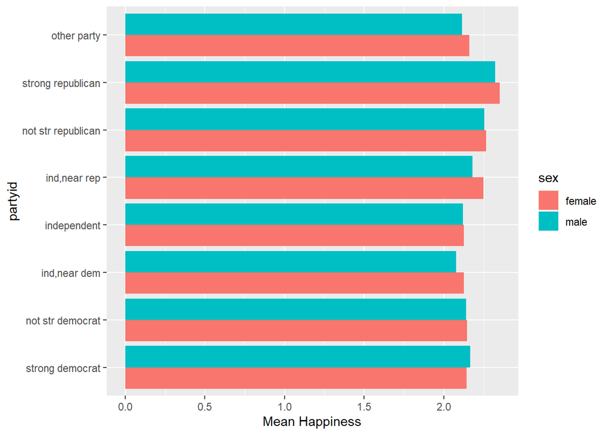

```r
#degree and health to happiness
na.omit(happy) %>% group_by(partyid, sex) %>% summarise(
  m.happiness = mean(as.numeric(happiness), na.rm=TRUE)) %>%
  ggplot(aes(x=partyid, fill=sex)) +
  geom_bar(aes(weight=m.happiness), position=position_dodge()) +
  ylab("Mean Happiness") +
  coord_flip()
```

### Ngoc question

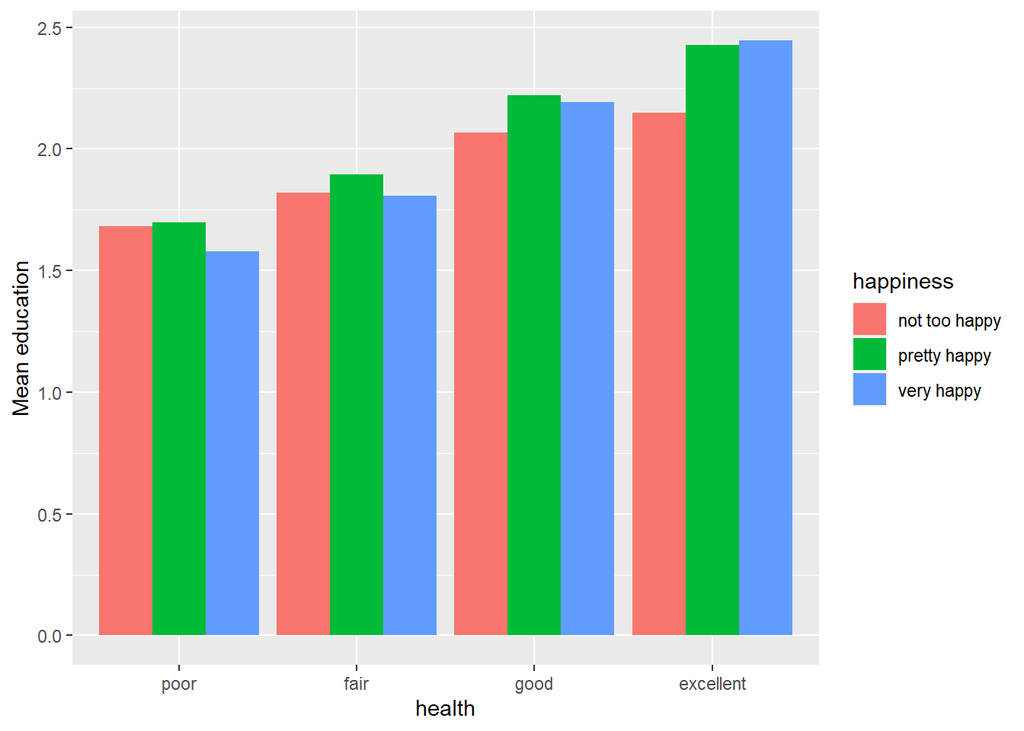

```r
na.omit(happy) %>% group_by(health, happiness) %>% summarise(
  m.degree = mean(as.numeric(degree), na.rm=TRUE)) %>%
  ggplot(aes(x=health, fill=happiness)) +
  geom_bar(aes(weight=m.degree), position=position_dodge()) +
  ylab("Mean education")
```